# player_data_notebook

```python
import pandas as pd
import numpy as np
from sklearn.metrics import accuracy_score, confusion_matrix, ConfusionMatrixDisplay, classification_report
from sklearn.linear_model import LogisticRegression
import xgboost as xgb
import warnings
import matplotlib.pyplot as plt
from sklearn.model_selection import train_test_split, GridSearchCV, learning_curve
from sklearn.utils.class_weight import compute_class_weight
from sklearn.impute import SimpleImputer
from sklearn.decomposition import PCA
from sklearn.preprocessing import StandardScaler
from sklearn.neighbors import KNeighborsClassifier
from xgboost import XGBClassifier, plot_importance
from imblearn.over_sampling import SMOTE
from sklearn.feature_selection import SelectFromModel
from sklearn.ensemble import RandomForestClassifier, VotingClassifier, GradientBoostingClassifier
from sklearn.neural_network import MLPClassifier
from catboost import CatBoostClassifier

warnings.filterwarnings('ignore')
```

```python
file_path = "C:/Users/samar/OneDrive/Desktop/mathapp/APST/dataChallenge"
```

```python
away_player_train = file_path + "/Train_Data/train_away_player_statistics_df.csv"
away_team_train = file_path + "/Train_Data/train_away_team_statistics_df.csv"
home_player_train = file_path + "/Train_Data/train_home_player_statistics_df.csv"
home_team_train = file_path + "/Train_Data/train_home_team_statistics_df.csv"
```

```python
away_player_test = file_path + "/Test_Data/test_away_player_statistics_df.csv"
away_team_test = file_path + "/Test_Data/test_away_team_statistics_df.csv"
home_player_test = file_path + "/Test_Data/test_home_player_statistics_df.csv"
home_team_test = file_path + "/Test_Data/test_home_team_statistics_df.csv"
```

```python
Y_train_supp = file_path + "/benchmark_and_extras/Y_train_supp.csv"
Y_train = file_path + "/Y_train.csv"
Y_test_random = file_path + "/Y_test_random.csv"
```

## Read player train data

```python
home_players = pd.read_csv(home_player_train)
away_players = pd.read_csv(away_player_train)

# team_name and league and player_name are not included in the test dataset so no need to use it
home_players = home_players.drop(columns=['TEAM_NAME', 'LEAGUE', 'PLAYER_NAME'])
away_players = away_players.drop(columns=['TEAM_NAME', 'LEAGUE', 'PLAYER_NAME'])

home_players['POSITION'] = home_players['POSITION'].replace({'defender': 1, 'midfielder': 2, 'attacker': 3, 'goalkeeper': 4, '': 0, np.nan: 0})
away_players['POSITION'] = away_players['POSITION'].replace({'defender': 1, 'midfielder': 2, 'attacker': 3, 'goalkeeper': 4, '': 0, np.nan: 0})
```

```python
# Aggregate player stats by ID and POSITION
home_team_stats = home_players.groupby(by = ['ID', 'POSITION'], as_index= False).mean().fillna(0)
away_team_stats = away_players.groupby(by = ['ID', 'POSITION'], as_index= False).mean().fillna(0)

team_comparison = pd.merge(home_team_stats, away_team_stats, on=['ID', 'POSITION'], suffixes=('_home', '_away'))
```

```python
team_comparison.head()
```

|  | ID | POSITION | PLAYER_ACCURATE_CROSSES_season_sum_home | PLAYER_ACCURATE_PASSES_season_sum_home | PLAYER_AERIALS_WON_season_sum_home | PLAYER_ASSISTS_season_sum_home | PLAYER_BIG_CHANCES_CREATED_season_sum_home | PLAYER_BIG_CHANCES_MISSED_season_sum_home | PLAYER_BLOCKED_SHOTS_season_sum_home | PLAYER_CAPTAIN_season_sum_home | ... | PLAYER_STARTING_LINEUP_5_last_match_std_away | PLAYER_SUCCESSFUL_DRIBBLES_5_last_match_std_away | PLAYER_TACKLES_5_last_match_std_away | PLAYER_TOTAL_CROSSES_5_last_match_std_away | PLAYER_TOTAL_DUELS_5_last_match_std_away | PLAYER_YELLOWCARDS_5_last_match_std_away | PLAYER_PUNCHES_5_last_match_std_away | PLAYER_LONG_BALLS_5_last_match_std_away | PLAYER_LONG_BALLS_WON_5_last_match_std_away | PLAYER_SHOTS_OFF_TARGET_5_last_match_std_away |
| --- | --- | --- | --- | --- | --- | --- | --- | --- | --- | --- | --- | --- | --- | --- | --- | --- | --- | --- | --- | --- | --- |
| 0 | 0 | 0.0 | 3.25 | 12.000000 | 21.250000 | 10.500000 | 6.000000 | 21.500000 | 3.000000 | 0.0 | ... | 36.166667 | 26.000000 | 21.000000 | 25.833333 | 35.333333 | 38.5 | 0.0 | 0.0 | 0.0 | 0.0 |
| 1 | 0 | 1.0 | 4.00 | 27.166667 | 22.166667 | 7.000000 | 5.333333 | 0.000000 | 17.500000 | 0.0 | ... | 17.500000 | 36.250000 | 40.000000 | 17.750000 | 42.250000 | 67.5 | 0.0 | 0.0 | 0.0 | 0.0 |
| 2 | 0 | 2.0 | 24.50 | 23.333333 | 9.166667 | 9.333333 | 12.333333 | 4.166667 | 8.166667 | 45.5 | ... | 28.000000 | 17.800000 | 26.200000 | 9.000000 | 33.400000 | 34.2 | 0.0 | 0.0 | 0.0 | 0.0 |
| 3 | 0 | 4.0 | 0.00 | 16.500000 | 1.000000 | 0.000000 | 0.000000 | 0.000000 | 0.000000 | 0.0 | ... | 0.000000 | 7.000000 | 0.000000 | 0.000000 | 2.000000 | 0.0 | 0.0 | 0.0 | 0.0 | 0.0 |
| 4 | 1 | 0.0 | 4.00 | 12.333333 | 13.000000 | 40.000000 | 20.666667 | 32.666667 | 2.666667 | 0.0 | ... | 72.333333 | 16.666667 | 6.666667 | 12.333333 | 34.666667 | 0.0 | 0.0 | 0.0 | 0.0 | 0.0 |

5 rows × 606 columns

```python
for column_name in team_comparison.columns:
    if column_name.endswith('_home'):  # Ensure we're processing only '_home' columns
        prefix = column_name[:-5]  # Remove '_home' to get the base column name
        team_comparison[prefix + '_diff'] = (
            team_comparison[column_name] - team_comparison[prefix + '_away']
        )
```

```python
team_comparison.head()
```

|  | ID | POSITION | PLAYER_ACCURATE_CROSSES_season_sum_home | PLAYER_ACCURATE_PASSES_season_sum_home | PLAYER_AERIALS_WON_season_sum_home | PLAYER_ASSISTS_season_sum_home | PLAYER_BIG_CHANCES_CREATED_season_sum_home | PLAYER_BIG_CHANCES_MISSED_season_sum_home | PLAYER_BLOCKED_SHOTS_season_sum_home | PLAYER_CAPTAIN_season_sum_home | ... | PLAYER_STARTING_LINEUP_5_last_match_std_diff | PLAYER_SUCCESSFUL_DRIBBLES_5_last_match_std_diff | PLAYER_TACKLES_5_last_match_std_diff | PLAYER_TOTAL_CROSSES_5_last_match_std_diff | PLAYER_TOTAL_DUELS_5_last_match_std_diff | PLAYER_YELLOWCARDS_5_last_match_std_diff | PLAYER_PUNCHES_5_last_match_std_diff | PLAYER_LONG_BALLS_5_last_match_std_diff | PLAYER_LONG_BALLS_WON_5_last_match_std_diff | PLAYER_SHOTS_OFF_TARGET_5_last_match_std_diff |
| --- | --- | --- | --- | --- | --- | --- | --- | --- | --- | --- | --- | --- | --- | --- | --- | --- | --- | --- | --- | --- | --- |
| 0 | 0 | 0.0 | 3.25 | 12.000000 | 21.250000 | 10.500000 | 6.000000 | 21.500000 | 3.000000 | 0.0 | ... | 33.833333 | -10.500000 | -12.000000 | -15.583333 | 5.416667 | 0.000000 | 0.0 | 0.0 | 0.0 | 0.0 |
| 1 | 0 | 1.0 | 4.00 | 27.166667 | 22.166667 | 7.000000 | 5.333333 | 0.000000 | 17.500000 | 0.0 | ... | 10.500000 | -16.850000 | -9.000000 | -5.150000 | -0.050000 | 12.900000 | 0.0 | 0.0 | 0.0 | 0.0 |
| 2 | 0 | 2.0 | 24.50 | 23.333333 | 9.166667 | 9.333333 | 12.333333 | 4.166667 | 8.166667 | 45.5 | ... | 5.833333 | 23.866667 | 13.800000 | 15.333333 | 14.766667 | -8.533333 | 0.0 | 0.0 | 0.0 | 0.0 |
| 3 | 0 | 4.0 | 0.00 | 16.500000 | 1.000000 | 0.000000 | 0.000000 | 0.000000 | 0.000000 | 0.0 | ... | 0.000000 | -7.000000 | 0.000000 | 0.000000 | -0.500000 | 0.000000 | 0.0 | 0.0 | 0.0 | 0.0 |
| 4 | 1 | 0.0 | 4.00 | 12.333333 | 13.000000 | 40.000000 | 20.666667 | 32.666667 | 2.666667 | 0.0 | ... | -72.333333 | -9.000000 | -2.666667 | -7.333333 | -16.000000 | 0.000000 | 0.0 | 0.0 | 0.0 | 0.0 |

5 rows × 908 columns

## Analyse des données

```python
print('dimension of the dataset:', away_players.shape)
print()
away_players.info()
```

```
dimension of the dataset: (236132, 304)

<class 'pandas.core.frame.DataFrame'>
RangeIndex: 236132 entries, 0 to 236131
Columns: 304 entries, ID to PLAYER_SHOTS_OFF_TARGET_5_last_match_std
dtypes: float64(303), int64(1)
memory usage: 547.7 MB
```

```python
print('dimension of the dataset:', home_players.shape)
print()
home_players.info()
```

```
dimension of the dataset: (237079, 304)

<class 'pandas.core.frame.DataFrame'>
RangeIndex: 237079 entries, 0 to 237078
Columns: 304 entries, ID to PLAYER_SHOTS_OFF_TARGET_5_last_match_std
dtypes: float64(303), int64(1)
memory usage: 549.9 MB
```

#### Analyse des données manquantes

```python
col_missing_away = away_players.isna().mean().sort_values(ascending=False)
col_missing_away
```

```
PLAYER_SHOTS_OFF_TARGET_season_std              1.000000
PLAYER_LONG_BALLS_5_last_match_sum              1.000000
PLAYER_SHOTS_OFF_TARGET_season_sum              1.000000
PLAYER_CAPTAIN_season_average                   1.000000
PLAYER_LONG_BALLS_season_average                1.000000
                                                  ...
PLAYER_MINUTES_PLAYED_5_last_match_average      0.016216
PLAYER_PENALTIES_SCORED_5_last_match_average    0.016216
PLAYER_STARTING_LINEUP_5_last_match_average     0.016216
POSITION                                        0.000000
ID                                              0.000000
Length: 304, dtype: float64
```

```python
col_missing_home = home_players.isna().mean().sort_values(ascending=False)
col_missing_home
```

```
PLAYER_SHOTS_OFF_TARGET_season_std              1.000000
PLAYER_LONG_BALLS_5_last_match_sum              1.000000
PLAYER_SHOTS_OFF_TARGET_season_sum              1.000000
PLAYER_CAPTAIN_season_average                   1.000000
PLAYER_LONG_BALLS_season_average                1.000000
                                                  ...
PLAYER_MINUTES_PLAYED_5_last_match_average      0.015172
PLAYER_PENALTIES_SCORED_5_last_match_average    0.015172
PLAYER_STARTING_LINEUP_5_last_match_average     0.015172
POSITION                                        0.000000
ID                                              0.000000
Length: 304, dtype: float64
```

Nous remarquons un nombre important des colonnes avec des données manquantes

```python
print(f'Percentage de colonnes avec de données manquantes dans away dataset: {len(col_missing_away[col_missing_away > 0])*100/len(col_missing_away):.3f} %')
print(f'Percentage de colonnes avec de données manquantes dans home dataset: {len(col_missing_home[col_missing_home > 0])*100/len(col_missing_home):.3f} %')
```

```
Percentage de colonnes avec de données manquantes dans away dataset: 99.342 %
Percentage de colonnes avec de données manquantes dans home dataset: 99.342 %
```

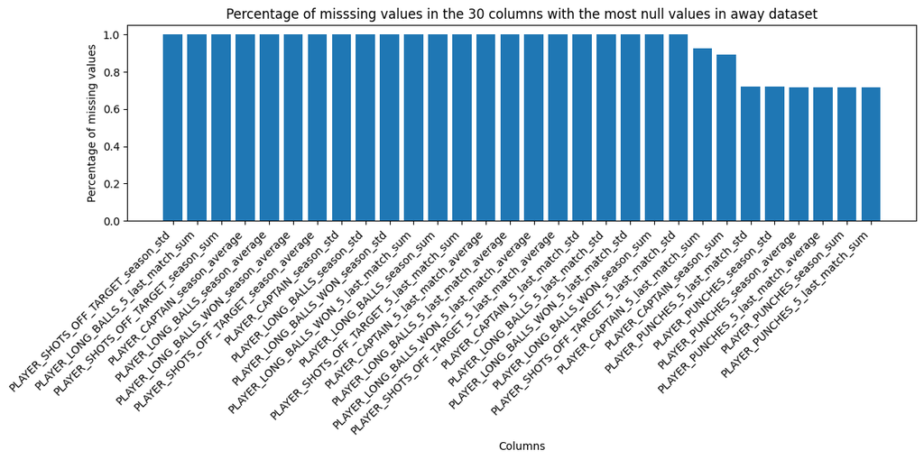

```python
top30_misv = col_missing_away.head(30)
fig, ax = plt.subplots(figsize = (12, 6))
ax.bar(top30_misv.index, top30_misv)
ax.set_xticklabels(top30_misv.index, rotation=45, ha='right')
ax.set_xlabel('Columns')
ax.set_ylabel('Percentage of missing values')
ax.set_title('Percentage of misssing values in the 30 columns with the most null values in away dataset')
plt.tight_layout()
plt.show()
```

[figure not shown]

```python
top30_misv = col_missing_away.head(30)
fig, ax = plt.subplots(figsize = (12, 6))
ax.bar(top30_misv.index, top30_misv)
ax.set_xticklabels(top30_misv.index, rotation=45, ha='right')
ax.set_xlabel('Columns')
ax.set_ylabel('Percentage of missing values')
ax.set_title('Percentage of misssing values in the 30 columns with the most null values in home dataset')
plt.tight_layout()
plt.show()
```

On efface les colonnés où il a plus de 30% de données manquantes

```python
cols_drop_away = col_missing_away[col_missing_away > 0.3].index
train_away_clean = away_players.drop(columns=cols_drop_away)
print('Shape initiale:', away_players.shape)
print('Shape finale:',train_away_clean.shape)
```

```
Shape initiale: (236132, 304)
Shape finale: (236132, 271)
```

```python
cols_drop_away = col_missing_home[col_missing_home > 0.3].index
train_home_clean = home_players.drop(columns=cols_drop_away)
print('Shape initiale:', home_players.shape)
print('Shape finale:',train_home_clean.shape)
```

```
Shape initiale: (237079, 304)
Shape finale: (237079, 271)
```

Analyse sur les lignes

```python
row_missing_away = away_players.isna().mean(axis=1).sort_values(ascending=False)
row_missing_away
```

```
88026     0.993421
171113    0.993421
90397     0.993421
90418     0.993421
222203    0.993421
            ...
84078     0.072368
19001     0.072368
160976    0.072368
160966    0.072368
200480    0.072368
Length: 236132, dtype: float64
```

```python
row_missing_home = home_players.isna().mean(axis=1).sort_values(ascending=False)
row_missing_home
```

```
57095     0.993421
156862    0.993421
108771    0.993421
196897    0.993421
196904    0.993421
            ...
186099    0.072368
96665     0.072368
80991     0.072368
80992     0.072368
43000     0.072368
Length: 237079, dtype: float64
```

```python
print(f'Percentage de lignes avec de données manquantes: {len(row_missing_away[row_missing_away > 0])*100/len(row_missing_away):.3f} %')
print(f'Percentage de lignes avec de données manquantes: {len(row_missing_home[row_missing_home > 0])*100/len(row_missing_home):.3f} %')
```

```
Percentage de lignes avec de données manquantes: 100.000 %
Percentage de lignes avec de données manquantes: 100.000 %
```

**Nous avons une quantité importante des données manquantes sur chaque ligne**

Dans ce cas, nous analysons les données de test des joeurs

```python
test_player_away = pd.read_csv(away_player_test)

row_missing_awya_test = test_player_away.isna().mean(axis=1).sort_values(ascending=False)
row_missing_awya_test
```

```
463137    0.996711
293598    0.996711
299252    0.996711
239328    0.996711
14985     0.996711
            ...
258513    0.013158
412803    0.013158
361948    0.013158
452679    0.013158
328452    0.013158
Length: 504626, dtype: float64
```

```python
test_player_home = pd.read_csv(home_player_test)
row_missing_home_test = test_player_home.isna().mean(axis=1).sort_values(ascending=False)
row_missing_home_test
```

```
400724    0.996711
427524    0.996711
411962    0.996711
386509    0.996711
271283    0.996711
            ...
224513    0.013158
224511    0.013158
442985    0.013158
101602    0.013158
128269    0.013158
Length: 509816, dtype: float64
```

```python
print(f'Percentage de lignes avec de données manquantes: {len(row_missing_awya_test[row_missing_awya_test > 0])*100/len(row_missing_awya_test):.3f} %')
print(f'Percentage de lignes avec de données manquantes: {len(row_missing_home_test[row_missing_home_test > 0])*100/len(row_missing_home_test):.3f} %')
```

```
Percentage de lignes avec de données manquantes: 100.000 %
Percentage de lignes avec de données manquantes: 100.000 %
```

Nous remarquons que dans les données de test il y a également beaucoup de données manquantes, avec des lignes qui manquent plus de 90% des données.

Dans ce cas, une imputation de données n'a pas du sense car dans certains cas nous allons imputer presque toute la ligne. Donc, les données des joueurs ne seront pas accurate mais en va quand même essayer de voir l'accuracy des predictions avec les datasets des joueurs.

## Entraînement de modèles

```python
# Load labels
labels = pd.read_csv(Y_train)

# Merge with features
data_with_labels = pd.merge(team_comparison, labels, how='right', on='ID')
```

```python
data_with_labels.head()
```

|  | ID | POSITION | PLAYER_ACCURATE_CROSSES_season_sum_home | PLAYER_ACCURATE_PASSES_season_sum_home | PLAYER_AERIALS_WON_season_sum_home | PLAYER_ASSISTS_season_sum_home | PLAYER_BIG_CHANCES_CREATED_season_sum_home | PLAYER_BIG_CHANCES_MISSED_season_sum_home | PLAYER_BLOCKED_SHOTS_season_sum_home | PLAYER_CAPTAIN_season_sum_home | ... | PLAYER_TOTAL_CROSSES_5_last_match_std_diff | PLAYER_TOTAL_DUELS_5_last_match_std_diff | PLAYER_YELLOWCARDS_5_last_match_std_diff | PLAYER_PUNCHES_5_last_match_std_diff | PLAYER_LONG_BALLS_5_last_match_std_diff | PLAYER_LONG_BALLS_WON_5_last_match_std_diff | PLAYER_SHOTS_OFF_TARGET_5_last_match_std_diff | HOME_WINS | DRAW | AWAY_WINS |
| --- | --- | --- | --- | --- | --- | --- | --- | --- | --- | --- | --- | --- | --- | --- | --- | --- | --- | --- | --- | --- | --- |
| 0 | 0 | 0.0 | 3.25 | 12.000000 | 21.250000 | 10.500000 | 6.000000 | 21.500000 | 3.000000 | 0.0 | ... | -15.583333 | 5.416667 | 0.000000 | 0.0 | 0.0 | 0.0 | 0.0 | 0 | 0 | 1 |
| 1 | 0 | 1.0 | 4.00 | 27.166667 | 22.166667 | 7.000000 | 5.333333 | 0.000000 | 17.500000 | 0.0 | ... | -5.150000 | -0.050000 | 12.900000 | 0.0 | 0.0 | 0.0 | 0.0 | 0 | 0 | 1 |
| 2 | 0 | 2.0 | 24.50 | 23.333333 | 9.166667 | 9.333333 | 12.333333 | 4.166667 | 8.166667 | 45.5 | ... | 15.333333 | 14.766667 | -8.533333 | 0.0 | 0.0 | 0.0 | 0.0 | 0 | 0 | 1 |
| 3 | 0 | 4.0 | 0.00 | 16.500000 | 1.000000 | 0.000000 | 0.000000 | 0.000000 | 0.000000 | 0.0 | ... | 0.000000 | -0.500000 | 0.000000 | 0.0 | 0.0 | 0.0 | 0.0 | 0 | 0 | 1 |
| 4 | 1 | 0.0 | 4.00 | 12.333333 | 13.000000 | 40.000000 | 20.666667 | 32.666667 | 2.666667 | 0.0 | ... | -7.333333 | -16.000000 | 0.000000 | 0.0 | 0.0 | 0.0 | 0.0 | 0 | 1 | 0 |

5 rows × 911 columns

```python
# Split data
X = data_with_labels.drop(['HOME_WINS', 'DRAW', 'AWAY_WINS'], axis=1).fillna(0)
y = data_with_labels[['HOME_WINS', 'DRAW', 'AWAY_WINS']].values.argmax(axis=1)

X_train, X_val, y_train, y_val = train_test_split(X, y, test_size=0.2, random_state=42)
```

```python
print(f"Nombre de données d'entrainement: {X_train.shape[0]}")
print(f"Nombre de données de test: {X_val.shape[0]}")
```

```
Nombre de données d'entrainement: 36912
Nombre de données de test: 9228
```

```python
y_train
```

```
array([2, 0, 1, ..., 0, 1, 0], dtype=int64)
```

### Imputation et standardisation des données

```python
imputer = SimpleImputer(strategy='median')
X_train_imp = imputer.fit_transform(X_train)

scaler = StandardScaler()
X_train_scaled = scaler.fit_transform(X_train_imp)
```

### Gradient Boosting Classifier

```python
params1 = {
    'n_estimators': 100,
    'learning_rate': 0.01,
    'max_depth': 5,
    'subsample': 0.9,
    'random_state': 42
}
gb_model = GradientBoostingClassifier(**params1)
```

```python
gb_model.fit(X_train_scaled, y_train)
```

```
GradientBoostingClassifier(random_state=42)
```

```python
y_pred = gb_model.predict(X_val)
print("Accuracy:", accuracy_score(y_val, y_pred))
```

```
Accuracy: 0.2874945817078457
```

find imporatance of the features

```python
print("Classification Report:\n", classification_report(y_val, y_pred))
```

```
Classification Report:
               precision    recall  f1-score   support

           0       0.49      0.13      0.21      4024
           1       0.26      0.85      0.39      2369
           2       0.38      0.04      0.08      2835

    accuracy                           0.29      9228
   macro avg       0.38      0.34      0.23      9228
weighted avg       0.40      0.29      0.21      9228
```

```python
# Feature Importance
importances = gb_model.feature_importances_
feature_names = X_train.columns
feature_importance = pd.DataFrame({'Feature': feature_names, 'Importance': importances})
feature_importance = feature_importance.sort_values(by='Importance', ascending=False).head(25)
print("Top 10 Features:\n", feature_importance)
```

```
Top 10 Features:
                                                Feature  Importance
676          PLAYER_GOALS_CONCEDED_season_average_diff    0.228651
657  PLAYER_ACCURATE_PASSES_PERCENTAGE_season_avera...    0.066354
656         PLAYER_ACCURATE_PASSES_season_average_diff    0.035514
727              PLAYER_GOALS_CONCEDED_season_std_diff    0.033241
0                                                   ID    0.025598
607             PLAYER_ACCURATE_PASSES_season_sum_diff    0.021111
661      PLAYER_BIG_CHANCES_MISSED_season_average_diff    0.017765
664              PLAYER_CLEARANCES_season_average_diff    0.016324
660     PLAYER_BIG_CHANCES_CREATED_season_average_diff    0.015921
609                     PLAYER_ASSISTS_season_sum_diff    0.014163
53   PLAYER_ACCURATE_PASSES_PERCENTAGE_season_avera...    0.013787
625                       PLAYER_GOALS_season_sum_diff    0.012053
675                   PLAYER_GOALS_season_average_diff    0.009920
173        PLAYER_GOALS_CONCEDED_5_last_match_sum_home    0.008885
425              PLAYER_GOALS_CONCEDED_season_std_away    0.008610
659                 PLAYER_ASSISTS_season_average_diff    0.008589
815        PLAYER_CLEARANCES_5_last_match_average_diff    0.007821
707             PLAYER_ACCURATE_PASSES_season_std_diff    0.007444
374          PLAYER_GOALS_CONCEDED_season_average_away    0.007390
878        PLAYER_GOALS_CONCEDED_5_last_match_std_diff    0.007221
525    PLAYER_GOALS_CONCEDED_5_last_match_average_away    0.006612
610         PLAYER_BIG_CHANCES_CREATED_season_sum_diff    0.006026
626              PLAYER_GOALS_CONCEDED_season_sum_diff    0.005807
576        PLAYER_GOALS_CONCEDED_5_last_match_std_away    0.005798
679              PLAYER_KEY_PASSES_season_average_diff    0.005565
```

[figure not shown]

```python
max_num_features = 25
top_features = feature_importance.head(max_num_features)

plt.figure(figsize=(10, 10))
plt.barh(top_features['Feature'], top_features['Importance'])
plt.xlabel('Importance')
plt.ylabel('Features')
plt.title(f'Top {max_num_features} Most Important Features in Random Forest')
plt.gca().invert_yaxis()
plt.tight_layout()
plt.show()
```

```python
n_features = X_train_scaled.shape[1]
total_pairs = n_features * (n_features - 1) // 2

correlation_matrix = X_train_scaled.corr()
high_corr_pairs = np.sum(np.triu(correlation_matrix > 0.9, k=1))

percentage_high_corr = (high_corr_pairs / total_pairs) * 100

print(f"Nombre total de paires: {total_pairs}")
print(f"Nombre de paires avec une corrélation > 0,9: {high_corr_pairs}")
print(f"Pourcentage de paires fortement corrélées: {percentage_high_corr:.2f}%")
```

```
Nombre total de paires: 411778
Nombre de paires avec une corrélation > 0,9: 875
Pourcentage de paires fortement corrélées: 0.21%
```

```python
pca = PCA(n_components=0.95)
X_train_pca = pca.fit_transform(X_train_scaled)
X_test_pca = pca.transform(X_val)

print(f"Nombre de composantes principales: {X_train_pca.shape[1]}")
```

```
Nombre de composantes principales: 1
```

```python
threshold = 0.003
important_features = feature_importance[feature_importance['Importance'] > threshold]

print(f"Nombre de features sélectionnées: {len(important_features)}")

selected_features_gb = important_features['Feature'].tolist()

X_train_selected = X_train_scaled[selected_features_gb]
X_test_selected = X_val[selected_features_gb]
```

```
Nombre de features sélectionnées: 25
```

```python
params = {
    'n_estimators': 200,
    'learning_rate': 0.01,
    'max_depth': 5,
    'subsample': 0.9,
    'random_state': 42
}
gb_model_selected = GradientBoostingClassifier(**params)
gb_model_selected.fit(X_train_selected, y_train)
y_pred = gb_model_selected.predict(X_test_selected)
```

```python
y_pred_selected = gb_model_selected.predict(X_test_selected)
score_gb_selected = accuracy_score(y_val, y_pred_selected)
score_gb_selected
```

```
0.4807108799306459
```

##### improve the model

```python
#Ensure consistent scaling for feature
scaler = StandardScaler()
X_train_scaled = scaler.fit_transform(X_train_scaled)
X_val_scaled = scaler.transform(X_val)

gb_model.fit(X_train_scaled, y_train)
y_pred = gb_model.predict(X_val_scaled)
print("Accuracy:", accuracy_score(y_val, y_pred))
```

```
Accuracy: 0.4845036844386649
```

```python
#Use SMOTE
sm = SMOTE(random_state=42)
X_train_resampled, y_train_resampled = sm.fit_resample(X_train_scaled, y_train)

gb_model.fit(X_train_resampled, y_train_resampled)
y_pred = gb_model.predict(X_val)
gb_smote_accuracy = accuracy_score(y_val, y_pred)
print("Accuracy:", gb_smote_accuracy)
```

[output not shown]

```python
#Reduce noise by selecting relevant features
feature_selector = SelectFromModel(gb_model, threshold='median')
X_train_selected = feature_selector.fit_transform(X_train_scaled, y_train)
X_val_selected = feature_selector.transform(X_val)

gb_model.fit(X_train_selected, y_train)
y_pred = gb_model.predict(X_val_selected)
gb_feature_seclection_accuracy = accuracy_score(y_val, y_pred)
print("Accuracy with Feature Selection:", gb_feature_seclection_accuracy)
```

[output not shown]

```python
#Use early stopping to avoid overfitting

model = GradientBoostingClassifier(
    n_estimators=1000,
    learning_rate=0.1,
    max_depth=5,
    subsample=0.8,
    random_state=42,
    validation_fraction=0.1,
    n_iter_no_change=10
)
model.fit(X_train_scaled, y_train)
y_pred = model.predict(X_val)
gb_early_stopping_accuracy = accuracy_score(y_val, y_pred)
print("Accuracy:", accuracy_score(y_val, y_pred))
```

[output not shown]

```
<sklearn.metrics._plot.confusion_matrix.ConfusionMatrixDisplay at 0x1e95fe63bb0>
```

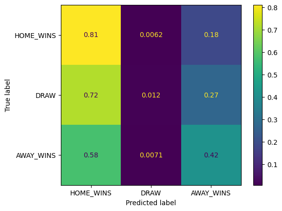

```python
cm = confusion_matrix(y_val, y_pred, normalize='true')
ConfusionMatrixDisplay(cm, display_labels=['HOME_WINS', 'DRAW', 'AWAY_WINS']).plot()
```

### XGBClassifier

Highly efficient for tabular data and supports multi-class classification. Offers regularization for better generalization.

```python
# Optimize Model Parameters
param_grid = {
    'max_depth': [8],
    'learning_rate': [0.01],
    'n_estimators': [1000],
    'colsample_bytree': [0.6],
    'subsample': [0.8],
}
grid_search = GridSearchCV(xgboost.XGBClassifier(objective='multi:softprob', num_class=3), param_grid, cv=3)
grid_search.fit(X_train_scaled, y_train)
print(grid_search.best_params_)
```

```
{'colsample_bytree': 0.6, 'learning_rate': 0.01, 'max_depth': 8, 'n_estimators': 1000, 'subsample': 0.8}
```

```python
params_1 = {
    'max_depth': 8,
    'learning_rate': 0.01,
    'n_estimators': 1000,
    'colsample_bytree': 0.6,
    'subsample': 0.8,
}
modelXGB = xgb.XGBClassifier(params_1)
modelXGB.fit(X_train_scaled, y_train)

# Evaluate
y_pred = modelXGB.predict(X_val)

print("Accuracy:", accuracy_score(y_val, y_pred))
```

```
Accuracy: 0.3339835283918509
```

```python
xgb_accuracy = accuracy_score(y_val, y_pred)
```

```
<sklearn.metrics._plot.confusion_matrix.ConfusionMatrixDisplay at 0x1e83a486c40>
```

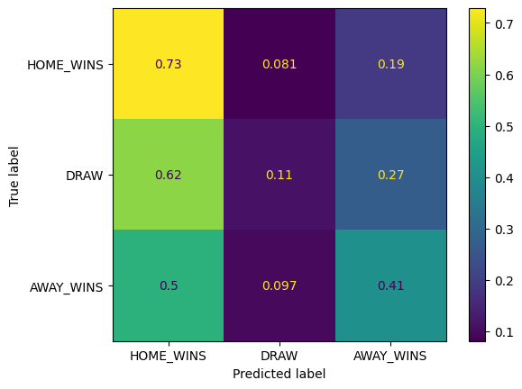

```python
cm = confusion_matrix(y_val, y_pred, normalize='true')
ConfusionMatrixDisplay(cm, display_labels=['HOME_WINS', 'DRAW', 'AWAY_WINS']).plot()
```

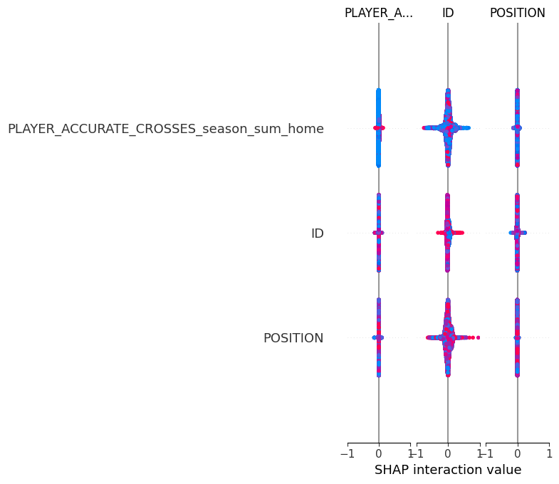

```python
#SHAP values can explain the influence of each feature (and its values) on individual predictions.
import shap

# Explain the model's predictions using SHAP
explainer = shap.TreeExplainer(modelXGB)
shap_values = explainer.shap_values(X_train_scaled)

# Visualize for 'POSITION'
shap.summary_plot(shap_values, X_train_scaled, feature_names=X_train.columns)
```

### Random Forest Classifier

Captures non-linear relationships and works well with feature importance analysis.

```python
# Random Forest Classifier
rf_model = RandomForestClassifier(n_estimators=100, random_state=42)
rf_model.fit(X_train_scaled, y_train)
rf_preds = rf_model.predict(X_val)
rf_accuracy = accuracy_score(y_val, rf_preds)
print("Accuracy:", rf_accuracy)
```

```
Accuracy: 0.4755093194625054
```

```python
# Hyperparameter Tuning for Random Forest
rf_params = {
    'n_estimators': [100],
    'max_depth': [10],
    'min_samples_split': [2],
}
grid_search_rf = GridSearchCV(RandomForestClassifier(random_state=42), rf_params, cv=5)
grid_search_rf.fit(X_train_scaled, y_train)
print(f"Best Random Forest Params: {grid_search_rf.best_params_}")
```

```
Best Random Forest Params: {'max_depth': 10, 'min_samples_split': 2, 'n_estimators': 100}
```

```python
# Random Forest Classifier
rf_model_improved = RandomForestClassifier(n_estimators= 100, random_state= 42, max_depth= 10, min_samples_split= 2)
rf_model_improved.fit(X_train_scaled, y_train)
rf_preds = rf_model_improved.predict(X_val)
rf_accuracy = accuracy_score(y_val, rf_preds)
print("Accuracy:", rf_accuracy)
```

```
Accuracy: 0.4822280017338535
```

### Logistic Regression

Simple and interpretable, suitable if the relationships are mostly linear.

```python
model_logistic_reg = LogisticRegression(multi_class='multinomial', solver='lbfgs', random_state=42)
model_logistic_reg.fit(X_train_scaled, y_train)
y_pred = model_logistic_reg.predict(X_val)
```

```python
accuracy = accuracy_score(y_val, y_pred)
print("Accuracy:", accuracy)
```

```
Accuracy: 0.47919375812743825
```

### Neural Networks

Effective if your dataset is large and complex. Can model interactions between features that traditional models might miss.

```python
nn_model = MLPClassifier(hidden_layer_sizes=(64, 32), activation='relu', random_state=42)
nn_model.fit(X_train_scaled, y_train)
y_pred = nn_model.predict(X_val)
accuracy = accuracy_score(y_val, y_pred)
print("Accuracy:", accuracy)
```

```
Accuracy: 0.39434330299089726
```

### Ensemble Methods

Combine predictions from multiple models (e.g., Random Forest + Gradient Boosting) to improve robustness.

```python
model1 = RandomForestClassifier(random_state=42)
model2 = GradientBoostingClassifier(random_state=42)
ensemble = VotingClassifier(estimators=[('rf', model1), ('gb', model2)], voting='soft')
ensemble.fit(X_train_scaled, y_train)
y_pred = ensemble.predict(X_val)
accuracy = accuracy_score(y_val, y_pred)
print("Accuracy:", accuracy)
```

```
Accuracy: 0.48255309926311224
```

### CatBoost

Handles categorical features without requiring one-hot encoding and is robust for tabular data.

```python
# Initialize the CatBoost model
catboost_model = CatBoostClassifier(iterations=500, depth=6, learning_rate=0.1, random_seed=42, verbose=0)

# Train the model
catboost_model.fit(X_train_scaled, y_train)

# Make predictions
catboost_preds = catboost_model.predict(X_val)

# Evaluate the model
catboost_accuracy = accuracy_score(y_val, catboost_preds)
print("CatBoost Accuracy:", catboost_accuracy)
```

```
CatBoost Accuracy: 0.4830949284785436
```

### K-Nearest Neighbors (KNN)

```python
# Initialize the KNN model
knn_model = KNeighborsClassifier(n_neighbors=5)

# Train the model
knn_model.fit(X_train_scaled, y_train)

# Make predictions
knn_preds = knn_model.predict(X_val)

# Evaluate the model
knn_accuracy = accuracy_score(y_val, knn_preds)
print("KNN Accuracy:", knn_accuracy)
```

```
KNN Accuracy: 0.41211530125704376
```

## Analyse du Score

```python
pd.DataFrame(
    {'score': [score_gb_selected, xgb_accuracy, rf_accuracy, accuracy, catboost_accuracy, knn_accuracy]},
    index=['score_gb_selected','xgb_accuracy', 'rf_accuracy', 'lg_accuracy', 'catboost_accuracy',
            'knn_accuracy']).sort_values(by='score', ascending=False)
```

|  | score |
| --- | --- |
| catboost_accuracy | 0.483095 |
| rf_accuracy | 0.482228 |
| score_gb_selected | 0.480711 |
| lg_accuracy | 0.479194 |
| knn_accuracy | 0.412115 |
| xgb_accuracy | 0.333984 |

#### Submission

```python
home_players_test = pd.read_csv(home_player_test)
away_players_test = pd.read_csv(away_player_test)

num_distinct_ids = home_players_test['ID'].nunique()
num_distinct_ids1 = away_players_test['ID'].nunique()
```

```python
home_players_test['POSITION'] = home_players_test['POSITION'].replace({'defender': 1, 'midfielder': 2, 'attacker': 3, 'goalkeeper': 4, '': 0, np.nan: 0})
away_players_test['POSITION'] = away_players_test['POSITION'].replace({'defender': 1, 'midfielder': 2, 'attacker': 3, 'goalkeeper': 4, '': 0, np.nan: 0})

num_distinct_ids2 = home_players_test['ID'].nunique()
num_distinct_ids3 = away_players_test['ID'].nunique()
```

```python
# Aggregate player stats by ID and POSITION
home_team_stats = home_players_test.groupby(by = ['ID', 'POSITION'], as_index=False).mean()
away_team_stats = away_players_test.groupby(by = ['ID', 'POSITION'], as_index=False).mean()
```

```python
# Merge on match ID and POSITION
team_comparison_test = pd.merge(home_team_stats, away_team_stats, on=['ID', 'POSITION'], suffixes=('_home', '_away'), how='outer').fillna(0)
```

```python
for column_name in team_comparison_test.columns:
    if column_name.endswith('_home'):  # Ensure we're processing only '_home' columns
        prefix = column_name[:-5]  # Remove '_home' to get the base column name
        team_comparison_test[prefix + '_diff'] = (
            team_comparison_test[column_name] - team_comparison_test[prefix + '_away']
        )
```

```python
def generate_test_submission(model, team_comparison_test):
    predictions = model.predict(team_comparison_test)
    team_comparison_test.set_index('ID', inplace=True)
    predictions_sub = np.zeros((predictions.size, 3))
    for i in range(predictions.size):
        predictions_sub[i][predictions[i]] = 1
    predictions_sub = pd.DataFrame(predictions_sub, dtype=int)
    predictions_sub.columns = ['HOME_WINS', 'DRAW', 'AWAY_WINS']

    predictions_sub.index = team_comparison_test.index
    submission = predictions_sub.reset_index()
    submission = submission.groupby('ID').sum().div(4).round().astype(int).reset_index()
    return submission
```

#### Gradient Boosting submission

```python
X_test_selected = team_comparison_test[selected_features_gb]
GB_submission = generate_test_submission(gb_model_selected, X_test_selected)
GB_submission.to_csv(file_path + "/submission_gb_player.csv", index=False) # 0.40373
```

#### RF Submission

```python
RF_submission = generate_test_submission(rf_model_improved, team_comparison_test)
RF_submission.to_csv(file_path + "/submission_rf.csv", index=False) #0.40586
```

#### Logistic Regression submission

```python
logistic_reg_submission = generate_test_submission(model_logistic_reg, team_comparison_test)
logistic_reg_submission.to_csv(file_path + "/submission_logistic_reg.csv", index=False) #0.40523
```

### Neural Network

```python
nn_submission = generate_test_submission(nn_model, team_comparison_test)
nn_submission.to_csv(file_path + "/submission_player_nn.csv", index=False) # 0.2241
```

#### Ensemble Methods submission

```python
ensemble_submission = generate_test_submission(ensemble, team_comparison_test)
ensemble_submission.to_csv(file_path + "/submission_player_ensemble.csv", index=False) #0.40917
```

#### XGBClassifier submission

```python
xgb_submission = generate_test_submission(modelXGB, team_comparison_test)
xgb_submission.to_csv(file_path + "/submission_player_xgb.csv", index=False) # 0.3279
```

### KNN

```python
knn_submission = generate_test_submission(knn_model, team_comparison_test)
knn_submission.to_csv(file_path + "/submission_player_knn.csv", index=False) # 0.218779
```

### Catboost

```python
catboost_submission = generate_test_submission(catboost_model, team_comparison_test)
catboost_submission.to_csv(file_path + "/submission_player_catboost.csv", index=False) # 0.38174
```